# R Notebook

# Case Study of Cyclistic

## About

Cyclistic is a bike-sharing company based in Chicago, IL. They offer several different types of passes: single-ride, full-day, or annual memberships. Casual riders are people who use either the single-ride pass or the full-day ride pass. Cyclystic members are the people with annual memberships.

Cyclistic would like to convert more casual riders to an annual membership for future growth and to maximize profits, however they need to know why people are choosing the different types of riding. To figure this out, they need to understand how people are using the bikes to better market the annual membership.

There are three questions they specifically want answered:

1. How do annual members and casual riders use Cyclistic bikes differently?
2. Why would casual riders buy Cyclistic annual memberships?
3. How can Cyclistic use digital media to influence casual riders to become members?

## Analysis

I am choosing to use R to analyze the data. I chose R because it can handle large amounts of data, it had cleaning tools built into it, and it has graphing and summarizing tools.

### Install and Load Packages

The first step is to install and load the packages needed. If the packages have not been installed yet, use install.packages(‘package_name’)

```r
#Load the packages
library(tidyverse)
library(janitor)
library(lubridate)
library(dplyr)
```

### Import Data

Now the data needs to be imported.

```r
#importing the data and naming them
Jan2023 <- read.csv("~/Desktop/Divvy_TripData/01_2023.csv")
Feb2023 <- read.csv("~/Desktop/Divvy_TripData/02_2023.csv")
Mar2023 <- read.csv("~/Desktop/Divvy_TripData/03_2023.csv")
Apr2023 <- read.csv("~/Desktop/Divvy_TripData/04_2023.csv")
May2023 <- read.csv("~/Desktop/Divvy_TripData/05_2023.csv")
Jun2023 <- read.csv("~/Desktop/Divvy_TripData/06_2023.csv")
Jul2023 <- read.csv("~/Desktop/Divvy_TripData/07_2023.csv")
Aug2023 <- read.csv("~/Desktop/Divvy_TripData/08_2023.csv")
Sep2023 <- read.csv("~/Desktop/Divvy_TripData/09_2023.csv")
Oct2023 <- read.csv("~/Desktop/Divvy_TripData/10_2023.csv")
Nov2023 <- read.csv("~/Desktop/Divvy_TripData/11_2023.csv")
Dec2023 <- read.csv("~/Desktop/Divvy_TripData/12_2023.csv")
```

### Clean and Manipulate Data

Now the data should be combined into one dataset, but all the column names and data types must be the same.

```r
#Return column names and types, along with other data
str(Jan2023)
```

```
'data.frame':   190301 obs. of  13 variables:
 $ ride_id           : chr  "F96D5A74A3E41399" "13CB7EB698CEDB88" "BD88A2E670661CE5" "C90792D034FED968" ...
 $ rideable_type     : chr  "electric_bike" "classic_bike" "electric_bike" "classic_bike" ...
 $ started_at        : chr  "2023-01-21 20:05:42" "2023-01-10 15:37:36" "2023-01-02 07:51:57" "2023-01-22 10:52:58" ...
 $ ended_at          : chr  "2023-01-21 20:16:33" "2023-01-10 15:46:05" "2023-01-02 08:05:11" "2023-01-22 11:01:44" ...
 $ start_station_name: chr  "Lincoln Ave & Fullerton Ave" "Kimbark Ave & 53rd St" "Western Ave & Lunt Ave" "Kimbark Ave & 53rd St" ...
 $ start_station_id  : chr  "TA1309000058" "TA1309000037" "RP-005" "TA1309000037" ...
 $ end_station_name  : chr  "Hampden Ct & Diversey Ave" "Greenwood Ave & 47th St" "Valli Produce - Evanston Plaza" "Greenwood Ave & 47th St" ...
 $ end_station_id    : chr  "202480.0" "TA1308000002" "599" "TA1308000002" ...
 $ start_lat         : num  41.9 41.8 42 41.8 41.8 ...
 $ start_lng         : num  -87.6 -87.6 -87.7 -87.6 -87.6 ...
 $ end_lat           : num  41.9 41.8 42 41.8 41.8 ...
 $ end_lng           : num  -87.6 -87.6 -87.7 -87.6 -87.6 ...
 $ member_casual     : chr  "member" "member" "casual" "member" ...
```

```r
str(Feb2023)
```

```
'data.frame':   190445 obs. of  13 variables:
 $ ride_id           : chr  "CBCD0D7777F0E45F" "F3EC5FCE5FF39DE9" "E54C1F27FA9354FF" "3D561E04F739CC45" ...
 $ rideable_type     : chr  "classic_bike" "electric_bike" "classic_bike" "electric_bike" ...
 $ started_at        : chr  "2023-02-14 11:59:42" "2023-02-15 13:53:48" "2023-02-19 11:10:57" "2023-02-26 16:12:05" ...
 $ ended_at          : chr  "2023-02-14 12:13:38" "2023-02-15 13:59:08" "2023-02-19 11:35:01" "2023-02-26 16:39:55" ...
 $ start_station_name: chr  "Southport Ave & Clybourn Ave" "Clarendon Ave & Gordon Ter" "Southport Ave & Clybourn Ave" "Southport Ave & Clybourn Ave" ...
 $ start_station_id  : chr  "TA1309000030" "13379" "TA1309000030" "TA1309000030" ...
 $ end_station_name  : chr  "Clark St & Schiller St" "Sheridan Rd & Lawrence Ave" "Aberdeen St & Monroe St" "Franklin St & Adams St (Temp)" ...
 $ end_station_id    : chr  "TA1309000024" "TA1309000041" "13156" "TA1309000008" ...
 $ start_lat         : num  41.9 42 41.9 41.9 41.8 ...
 $ start_lng         : num  -87.7 -87.6 -87.7 -87.7 -87.6 ...
 $ end_lat           : num  41.9 42 41.9 41.9 41.8 ...
 $ end_lng           : num  -87.6 -87.7 -87.7 -87.6 -87.6 ...
 $ member_casual     : chr  "casual" "casual" "member" "member" ...
```

```r
str(Mar2023)
```

```
'data.frame':   258678 obs. of  13 variables:
 $ ride_id           : chr  "6842AA605EE9FBB3" "F984267A75B99A8C" "FF7CF57CFE026D02" "6B61B916032CB6D6" ...
 $ rideable_type     : chr  "electric_bike" "electric_bike" "classic_bike" "classic_bike" ...
 $ started_at        : chr  "2023-03-16 08:20:34" "2023-03-04 14:07:06" "2023-03-31 12:28:09" "2023-03-22 14:09:08" ...
 $ ended_at          : chr  "2023-03-16 08:22:52" "2023-03-04 14:15:31" "2023-03-31 12:38:47" "2023-03-22 14:24:51" ...
 $ start_station_name: chr  "Clark St & Armitage Ave" "Public Rack - Kedzie Ave & Argyle St" "Orleans St & Chestnut St (NEXT Apts)" "Desplaines St & Kinzie St" ...
 $ start_station_id  : chr  "13146" "491" "620" "TA1306000003" ...
 $ end_station_name  : chr  "Larrabee St & Webster Ave" "" "Clark St & Randolph St" "Sheffield Ave & Kingsbury St" ...
 $ end_station_id    : chr  "13193" "" "TA1305000030" "13154" ...
 $ start_lat         : num  41.9 42 41.9 41.9 41.9 ...
 $ start_lng         : num  -87.6 -87.7 -87.6 -87.6 -87.7 ...
 $ end_lat           : num  41.9 42 41.9 41.9 41.9 ...
 $ end_lng           : num  -87.6 -87.7 -87.6 -87.7 -87.7 ...
 $ member_casual     : chr  "member" "member" "member" "member" ...
```

```r
str(Apr2023)
```

```
'data.frame':   426590 obs. of  13 variables:
 $ ride_id           : chr  "8FE8F7D9C10E88C7" "34E4ED3ADF1D821B" "5296BF07A2F77CB5" "40759916B76D5D52" ...
 $ rideable_type     : chr  "electric_bike" "electric_bike" "electric_bike" "electric_bike" ...
 $ started_at        : chr  "2023-04-02 08:37:28" "2023-04-19 11:29:02" "2023-04-19 08:41:22" "2023-04-19 13:31:30" ...
 $ ended_at          : chr  "2023-04-02 08:41:37" "2023-04-19 11:52:12" "2023-04-19 08:43:22" "2023-04-19 13:35:09" ...
 $ start_station_name: chr  "" "" "" "" ...
 $ start_station_id  : chr  "" "" "" "" ...
 $ end_station_name  : chr  "" "" "" "" ...
 $ end_station_id    : chr  "" "" "" "" ...
 $ start_lat         : num  41.8 41.9 41.9 41.9 41.9 ...
 $ start_lng         : num  -87.6 -87.7 -87.7 -87.7 -87.7 ...
 $ end_lat           : num  41.8 41.9 41.9 41.9 41.9 ...
 $ end_lng           : num  -87.6 -87.7 -87.7 -87.7 -87.6 ...
 $ member_casual     : chr  "member" "member" "member" "member" ...
```

```r
str(May2023)
```

```
'data.frame':   604827 obs. of  13 variables:
 $ ride_id           : chr  "0D9FA920C3062031" "92485E5FB5888ACD" "FB144B3FC8300187" "DDEB93BC2CE9AA77" ...
 $ rideable_type     : chr  "electric_bike" "electric_bike" "electric_bike" "classic_bike" ...
 $ started_at        : chr  "2023-05-07 19:53:48" "2023-05-06 18:54:08" "2023-05-21 00:40:21" "2023-05-10 16:47:01" ...
 $ ended_at          : chr  "2023-05-07 19:58:32" "2023-05-06 19:03:35" "2023-05-21 00:44:36" "2023-05-10 16:59:52" ...
 $ start_station_name: chr  "Southport Ave & Belmont Ave" "Southport Ave & Belmont Ave" "Halsted St & 21st St" "Carpenter St & Huron St" ...
 $ start_station_id  : chr  "13229" "13229" "13162" "13196" ...
 $ end_station_name  : chr  "" "" "" "Damen Ave & Cortland St" ...
 $ end_station_id    : chr  "" "" "" "13133" ...
 $ start_lat         : num  41.9 41.9 41.9 41.9 42 ...
 $ start_lng         : num  -87.7 -87.7 -87.6 -87.7 -87.7 ...
 $ end_lat           : num  41.9 41.9 41.9 41.9 41.9 ...
 $ end_lng           : num  -87.7 -87.7 -87.7 -87.7 -87.7 ...
 $ member_casual     : chr  "member" "member" "member" "member" ...
```

```r
str(Jun2023)
```

```
'data.frame':   719618 obs. of  13 variables:
 $ ride_id           : chr  "6F1682AC40EB6F71" "622A1686D64948EB" "3C88859D926253B4" "EAD8A5E0259DEC88" ...
 $ rideable_type     : chr  "electric_bike" "electric_bike" "electric_bike" "electric_bike" ...
 $ started_at        : chr  "2023-06-05 13:34:12" "2023-06-05 01:30:22" "2023-06-20 18:15:49" "2023-06-19 14:56:00" ...
 $ ended_at          : chr  "2023-06-05 14:31:56" "2023-06-05 01:33:06" "2023-06-20 18:32:05" "2023-06-19 15:00:35" ...
 $ start_station_name: chr  "" "" "" "" ...
 $ start_station_id  : chr  "" "" "" "" ...
 $ end_station_name  : chr  "" "" "" "" ...
 $ end_station_id    : chr  "" "" "" "" ...
 $ start_lat         : num  41.9 41.9 42 42 42 ...
 $ start_lng         : num  -87.7 -87.7 -87.7 -87.7 -87.7 ...
 $ end_lat           : num  41.9 41.9 41.9 42 42 ...
 $ end_lng           : num  -87.7 -87.7 -87.6 -87.7 -87.7 ...
 $ member_casual     : chr  "member" "member" "member" "member" ...
```

```r
str(Jul2023)
```

```
'data.frame':   767650 obs. of  13 variables:
 $ ride_id           : chr  "9340B064F0AEE130" "D1460EE3CE0D8AF8" "DF41BE31B895A25E" "9624A293749EF703" ...
 $ rideable_type     : chr  "electric_bike" "classic_bike" "classic_bike" "electric_bike" ...
 $ started_at        : chr  "2023-07-23 20:06:14" "2023-07-23 17:05:07" "2023-07-23 10:14:53" "2023-07-21 08:27:44" ...
 $ ended_at          : chr  "2023-07-23 20:22:44" "2023-07-23 17:18:37" "2023-07-23 10:24:29" "2023-07-21 08:32:40" ...
 $ start_station_name: chr  "Kedzie Ave & 110th St" "Western Ave & Walton St" "Western Ave & Walton St" "Racine Ave & Randolph St" ...
 $ start_station_id  : chr  "20204" "KA1504000103" "KA1504000103" "13155" ...
 $ end_station_name  : chr  "Public Rack - Racine Ave & 109th Pl" "Milwaukee Ave & Grand Ave" "Damen Ave & Pierce Ave" "Clinton St & Madison St" ...
 $ end_station_id    : chr  "877" "13033" "TA1305000041" "TA1305000032" ...
 $ start_lat         : num  41.7 41.9 41.9 41.9 42 ...
 $ start_lng         : num  -87.7 -87.7 -87.7 -87.7 -87.7 ...
 $ end_lat           : num  41.7 41.9 41.9 41.9 42 ...
 $ end_lng           : num  -87.7 -87.6 -87.7 -87.6 -87.6 ...
 $ member_casual     : chr  "member" "member" "member" "member" ...
```

```r
str(Aug2023)
```

```
'data.frame':   771693 obs. of  13 variables:
 $ ride_id           : chr  "903C30C2D810A53B" "F2FB18A98E110A2B" "D0DEC7C94E4663DA" "E0DDDC5F84747ED9" ...
 $ rideable_type     : chr  "electric_bike" "electric_bike" "electric_bike" "electric_bike" ...
 $ started_at        : chr  "2023-08-19 15:41:53" "2023-08-18 15:30:18" "2023-08-30 16:15:08" "2023-08-30 16:24:07" ...
 $ ended_at          : chr  "2023-08-19 15:53:36" "2023-08-18 15:45:25" "2023-08-30 16:27:37" "2023-08-30 16:33:34" ...
 $ start_station_name: chr  "LaSalle St & Illinois St" "Clark St & Randolph St" "Clark St & Randolph St" "Wells St & Elm St" ...
 $ start_station_id  : chr  "13430" "TA1305000030" "TA1305000030" "KA1504000135" ...
 $ end_station_name  : chr  "Clark St & Elm St" "" "" "" ...
 $ end_station_id    : chr  "TA1307000039" "" "" "" ...
 $ start_lat         : num  41.9 41.9 41.9 41.9 41.9 ...
 $ start_lng         : num  -87.6 -87.6 -87.6 -87.6 -87.6 ...
 $ end_lat           : num  41.9 41.9 41.9 41.9 41.9 ...
 $ end_lng           : num  -87.6 -87.6 -87.6 -87.6 -87.7 ...
 $ member_casual     : chr  "member" "member" "member" "member" ...
```

```r
str(Sep2023)
```

```
'data.frame':   666371 obs. of  13 variables:
 $ ride_id           : chr  "011C1903BF4E2E28" "87DB80E048A1BF9F" "7C2EB7AF669066E3" "57D197B010269CE3" ...
 $ rideable_type     : chr  "classic_bike" "classic_bike" "electric_bike" "classic_bike" ...
 $ started_at        : chr  "2023-09-23 00:27:50" "2023-09-02 09:26:43" "2023-09-25 18:30:11" "2023-09-13 15:30:49" ...
 $ ended_at          : chr  "2023-09-23 00:33:27" "2023-09-02 09:38:19" "2023-09-25 18:41:39" "2023-09-13 15:39:18" ...
 $ start_station_name: chr  "Halsted St & Wrightwood Ave" "Clark St & Drummond Pl" "Financial Pl & Ida B Wells Dr" "Clark St & Drummond Pl" ...
 $ start_station_id  : chr  "TA1309000061" "TA1307000142" "SL-010" "TA1307000142" ...
 $ end_station_name  : chr  "Sheffield Ave & Wellington Ave" "Racine Ave & Fullerton Ave" "Racine Ave & 15th St" "Racine Ave & Belmont Ave" ...
 $ end_station_id    : chr  "TA1307000052" "TA1306000026" "13304" "TA1308000019" ...
 $ start_lat         : num  41.9 41.9 41.9 41.9 41.9 ...
 $ start_lng         : num  -87.6 -87.6 -87.6 -87.6 -87.6 ...
 $ end_lat           : num  41.9 41.9 41.9 41.9 41.9 ...
 $ end_lng           : num  -87.7 -87.7 -87.7 -87.7 -87.7 ...
 $ member_casual     : chr  "member" "member" "member" "member" ...
```

```r
str(Oct2023)
```

```
'data.frame':   537113 obs. of  13 variables:
 $ ride_id           : chr  "4449097279F8BBE7" "9CF060543CA7B439" "667F21F4D6BDE69C" "F92714CC6B019B96" ...
 $ rideable_type     : chr  "classic_bike" "electric_bike" "electric_bike" "classic_bike" ...
 $ started_at        : chr  "2023-10-08 10:36:26" "2023-10-11 17:23:59" "2023-10-12 07:02:33" "2023-10-24 19:13:03" ...
 $ ended_at          : chr  "2023-10-08 10:49:19" "2023-10-11 17:36:08" "2023-10-12 07:06:53" "2023-10-24 19:18:29" ...
 $ start_station_name: chr  "Orleans St & Chestnut St (NEXT Apts)" "Desplaines St & Kinzie St" "Orleans St & Chestnut St (NEXT Apts)" "Desplaines St & Kinzie St" ...
 $ start_station_id  : chr  "620" "TA1306000003" "620" "TA1306000003" ...
 $ end_station_name  : chr  "Sheffield Ave & Webster Ave" "Sheffield Ave & Webster Ave" "Franklin St & Lake St" "Franklin St & Lake St" ...
 $ end_station_id    : chr  "TA1309000033" "TA1309000033" "TA1307000111" "TA1307000111" ...
 $ start_lat         : num  41.9 41.9 41.9 41.9 41.9 ...
 $ start_lng         : num  -87.6 -87.6 -87.6 -87.6 -87.6 ...
 $ end_lat           : num  41.9 41.9 41.9 41.9 41.9 ...
 $ end_lng           : num  -87.7 -87.7 -87.6 -87.6 -87.6 ...
 $ member_casual     : chr  "member" "member" "member" "member" ...
```

```r
str(Nov2023)
```

```
'data.frame':   362518 obs. of  13 variables:
 $ ride_id           : chr  "4EAD8F1AD547356B" "6322270563BF5470" "B37BDE091ECA38E0" "CF0CA5DD26E4F90E" ...
 $ rideable_type     : chr  "electric_bike" "electric_bike" "electric_bike" "classic_bike" ...
 $ started_at        : chr  "2023-11-30 21:50:05" "2023-11-03 09:44:02" "2023-11-30 11:39:44" "2023-11-08 10:01:45" ...
 $ ended_at          : chr  "2023-11-30 22:13:27" "2023-11-03 10:17:15" "2023-11-30 11:40:08" "2023-11-08 10:27:05" ...
 $ start_station_name: chr  "Millennium Park" "Broadway & Sheridan Rd" "State St & Pearson St" "Theater on the Lake" ...
 $ start_station_id  : chr  "13008" "13323" "TA1307000061" "TA1308000001" ...
 $ end_station_name  : chr  "Pine Grove Ave & Waveland Ave" "Broadway & Sheridan Rd" "State St & Pearson St" "Theater on the Lake" ...
 $ end_station_id    : chr  "TA1307000150" "13323" "TA1307000061" "TA1308000001" ...
 $ start_lat         : num  41.9 42 41.9 41.9 41.9 ...
 $ start_lng         : num  -87.6 -87.7 -87.6 -87.6 -87.6 ...
 $ end_lat           : num  41.9 42 41.9 41.9 41.9 ...
 $ end_lng           : num  -87.6 -87.6 -87.6 -87.6 -87.6 ...
 $ member_casual     : chr  "member" "member" "member" "member" ...
```

```r
str(Dec2023)
```

```
'data.frame':   224073 obs. of  13 variables:
 $ ride_id           : chr  "C9BD54F578F57246" "CDBD92F067FA620E" "ABC0858E52CBFC84" "F44B6F0E8F76DC90" ...
 $ rideable_type     : chr  "electric_bike" "electric_bike" "electric_bike" "electric_bike" ...
 $ started_at        : chr  "2023-12-02 18:44:01" "2023-12-02 18:48:19" "2023-12-24 01:56:32" "2023-12-24 10:58:12" ...
 $ ended_at          : chr  "2023-12-02 18:47:51" "2023-12-02 18:54:48" "2023-12-24 02:04:09" "2023-12-24 11:03:04" ...
 $ start_station_name: chr  "" "" "" "" ...
 $ start_station_id  : chr  "" "" "" "" ...
 $ end_station_name  : chr  "" "" "" "" ...
 $ end_station_id    : chr  "" "" "" "" ...
 $ start_lat         : num  41.9 41.9 41.9 42 41.9 ...
 $ start_lng         : num  -87.7 -87.7 -87.6 -87.7 -87.6 ...
 $ end_lat           : num  41.9 41.9 41.9 41.9 41.9 ...
 $ end_lng           : num  -87.7 -87.6 -87.6 -87.7 -87.6 ...
 $ member_casual     : chr  "member" "member" "member" "member" ...
```

Based on the above, each of these datasets have 13 variables:

| Variable |  | Type |  |
| --- | --- | --- | --- |
| ride_id | chr |  |  |
| rideable_type | chr |  |  |
| started_at | chr |  |  |
| ended_at | chr |  |  |
| start_station_name | chr |  |  |
| start_station_id | chr |  |  |
| end_station_name | chr |  |  |
| end_station_id | chr |  |  |
| start_lat | num |  |  |
| start_lng | num |  |  |
| end_lat | num |  |  |
| end_lng | num |  |  |
| member_casual | chr |  |  |

Since they all have the same variables and the same types for the variables, they can be combined to one dataset.

```r
#Bind all dataframes to one dataframe
all2023 <- bind_rows(Jan2023, Feb2023, Mar2023, Apr2023, May2023, Jun2023, Jul2023, Aug2023, Sep2023, Oct2023, Nov2023, Dec2023)
```

Now the data can be cleaned further by removing extra spaces in the column names, making sure the data is the same format (no random capitalization).

```r
#clean. remove spaces, etc.
all2023clean <- clean_names(all2023)
```

Now we want the start and end times to be in time format, not character

```r
#Format started_at and ended_at as time
all2023clean$started_at <- as.POSIXct(all2023clean$started_at, format = "%Y-%m-%d %H:%M:%S")
all2023clean$ended_at <- as.POSIXct(all2023clean$ended_at, format = "%Y-%m-%d %H:%M:%S")
```

To make sure this was done correctly, we can use str again, if the dates are now POSIXct format, it was done correctly

```r
str(all2023clean)
```

```
'data.frame':   5719877 obs. of  13 variables:
 $ ride_id           : chr  "F96D5A74A3E41399" "13CB7EB698CEDB88" "BD88A2E670661CE5" "C90792D034FED968" ...
 $ rideable_type     : chr  "electric_bike" "classic_bike" "electric_bike" "classic_bike" ...
 $ started_at        : POSIXct, format: "2023-01-21 20:05:42" ...
 $ ended_at          : POSIXct, format: "2023-01-21 20:16:33" ...
 $ start_station_name: chr  "Lincoln Ave & Fullerton Ave" "Kimbark Ave & 53rd St" "Western Ave & Lunt Ave" "Kimbark Ave & 53rd St" ...
 $ start_station_id  : chr  "TA1309000058" "TA1309000037" "RP-005" "TA1309000037" ...
 $ end_station_name  : chr  "Hampden Ct & Diversey Ave" "Greenwood Ave & 47th St" "Valli Produce - Evanston Plaza" "Greenwood Ave & 47th St" ...
 $ end_station_id    : chr  "202480.0" "TA1308000002" "599" "TA1308000002" ...
 $ start_lat         : num  41.9 41.8 42 41.8 41.8 ...
 $ start_lng         : num  -87.6 -87.6 -87.7 -87.6 -87.6 ...
 $ end_lat           : num  41.9 41.8 42 41.8 41.8 ...
 $ end_lng           : num  -87.6 -87.6 -87.7 -87.6 -87.6 ...
 $ member_casual     : chr  "member" "member" "casual" "member" ...
```

With the start and end times in the correct format, we can now calculate the ride_length

```r
#add ride_length column
all2023clean <- all2023clean %>%
  mutate(ride_length= ended_at - started_at)
```

We also want to have another column with the day of the week, using wday() and label=TRUE so the column will have the days of the week written out instead of numbers.

```r
#add day_of_week column
all2023clean <- all2023clean %>%
  mutate(day_of_week=wday(started_at, label=TRUE))
```

As well as for the month, using the month() function with label=TRUE, so the column will be the month names instead of numbers.

```r
#add the_month column
all2023clean <- all2023clean %>%
  mutate(the_month=month(started_at, label=TRUE))
```

We can also graph the hours that people ride during, but we would need separate columns for just the times each ride started. To simplify this, I am just getting the hour, because we don’t need an exact time, just a time of day.

```r
#column for start_time and end_time
all2023clean <- all2023clean %>%
  mutate(start_time=started_at %>% hour)

all2023clean <- all2023clean %>%
  mutate(end_time=ended_at %>% hour)
```

Now we can write this new dataframe to a csv file to be used in Tableau or other applications.

```r
write.csv(all2023clean, file="Cyclisticdata.csv")
```

### Data calculations

Now we can use all of these new columns to calculate more data that will be useful for analysis.

The first things we are going to calculate is the average ride length for both casual riders and members.

```r
all2023clean %>%
  group_by(member_casual) %>%
  summarise(mean(ride_length))
```

| member_casual | mean(ride_length) |
| --- | --- |
| casual | 1693.5033 secs |
| member | 750.8116 secs |

```r
NA
```

This gives us:  
casual 1693.5033 seconds or around 30 minutes  
member 750.8116 seconds or around 12.5 minutes  
This shows us that casual riders are using the bikes for longer periods of time than members.

### Graphs

We can also use a graph to see what the most popular days of the week are for using the bikes.

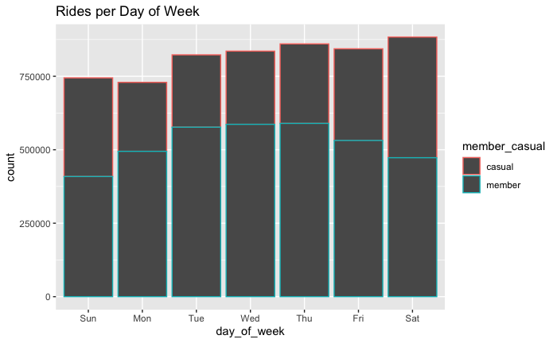

```r
#Graph popular days of the week by rider type
ggplot(data = all2023clean) +
  geom_bar(mapping=aes(x=day_of_week, color=member_casual)) +
  ggtitle("Rides per Day of Week")
```

Based on this graph, it looks like casual riders normally ride more during the weekends, and members ride more during the week.

We can also graph the months different riders ride during.

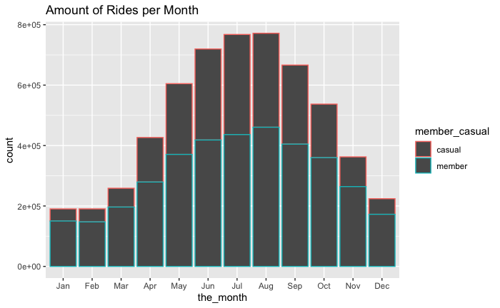

```r
#The months people ride during
ggplot(data=all2023clean) +
  geom_bar(mapping=aes(x=the_month, color=member_casual)) +
  ggtitle("Amount of Rides per Month")
```

This graph shows that all ridership is increased during the warmer months, but it especially increases for casual riders, with the most riders being in July and August.

We can also graph the times people bike, during the different days of the week.

```r
ggplot(data=all2023clean) +
  geom_bar(mapping=aes(x=start_time, color=member_casual)) +
  facet_wrap(~day_of_week) +
  ggtitle("Rides per Hour per Day of the Week")
```

[output not shown]

### Tableau

We can also utilize Tableau to make graphs and plot data This first image is a graph depicting the popular stations my rider type.

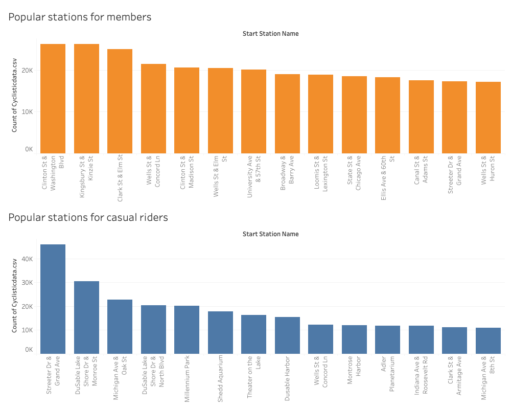

As shown in the graph, the 10 most popular stations for members are:

1. Clinton St & Washington Blvd
2. Kingsbury St & Kinzie St
3. Clark St & Elm St
4. Wells St & Concord Ln
5. Clinton St & Madison St
6. Wells St & Elm St
7. University Ave & 57th St
8. Broadway & Barry Ave
9. Loomis St & Lexington St
10. State St & Chicago Ave

The 10 most popular stations for casual riders are:

1. Streeter Dr & Grand Ave
2. DuSable Lake Shore Dr & Monroe St
3. Michigan Ave & Oak St
4. Dusable Lake Shore Dr & North Blvd
5. Millenium Park
6. Shedd Aquarium
7. Theater on the Lake
8. Dusable Harbor
9. Wells St & Concord Ln
10. Montrose Harbor

We can also use the latitude and longitude values we have to graph the data.

[figure not shown]

The image below includes a filter only showing stations that have had 10,000 or more starts.

[figure not shown]

I also used the names of the top 10 stations and plotted them on Google Maps so I could zoom in and see why people might be in the area. For casual riders, 9/10 of them were near parks and/or major attractions. For members, they seemed to be near homes or businesses.  
Popular Casual Stations:

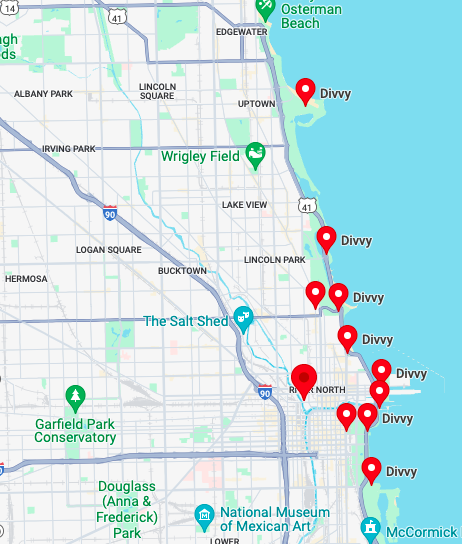

Popular Member Stations:

[figure not shown]

### Summary of Data

According to the data, casual riders:

- ride for an average of 30 minutes
- The most popular day of the week is Saturday
- Ridership increases during the warmer months, but drastically during the summer months
- A large number of rides start near parks and/or major attractions

### What does the data mean?

1. In answer to the first question Cyclistic would like answered (How do annual members and casual riders use Cyclistic bikes differently?): Based on the data I would infer that casual riders are sightseers. They bike for longer periods of time, in areas with a lot of sightseeing. They ridership of casual riders also increases drastically during the summer months, when children are out of school and people tend to plan vacations. The most popular day of the week is also Saturday, which is a popular day to get out of the house and do activities because most people have the day off. I would also infer that members live in Chicago and use the bikes for their day to day living, like going to work or to the gym. They tend to bike for shorter periods of time and they tend to start near areas with a lot of houses or by businesses. The most popular days for biking are Tuesday-Thursday, which is when most people work.
2. To answer the second question (Why would casual riders buy Cyclistic annual memberships?): There are a few reasons why I think casual riders would buy an annual membership instead of the casual ride pass. The first reason would be if it made the most sense financially. The second would be if there were extra incentives with an annual membership. If someone is only in the city for a short time, they probably won’t see the need to spend extra money on an annual pass if they wouldn’t use it. However, if there were changes made to the annual pass to make it more worth it for them, then they might consider it. One incentive would be access to guided tours, so they could explore different parts of the city. These could be access via their smartphone. Another incentive would be to have a minimum ride amount, where the pass will expire in a year or, if they haven’t ridden x number of times by that time, then it would be valid until they have ridden x number of times. They could also work with local businesses to provide discounts. Another incentive would be if they could get a discount off of the annual membership based on how many casual rides they’ve done. Sometimes, customers like to try something out before spending a lot of money.
3. To answer the third question (How can Cyclistic use digital media to influence casual riders to become members)? Digital media is everywhere. Advertisements online can go a long way. I think Cyclistic could use Instagram, TikTok, and YouTube ads to promote their bikes. A good incentive for casual riders would be to offer coupon codes through the advertisements. They should also make sure to include more advertisements near the popular biking areas. Another way is to use influencers to promote the bikes and the perks of an annual membership.

### Conclusion

To conclude: Currently, casual riders tend to be tourists and ride longer periods of time in the areas with attractions. Members, tend to right for shorter periods of time and in areas with businesses and homes. To get more casual riders to become annual members, Cyclistic should use more advertisements in the popular tourists areas and through popular social media websites that offer discount codes, push the annual membership by including guided tours or coupons with the purchase, and have influencers showcase the bikes.